# week 3: individual behavior

Daijiang Li

## Reading:

Croteau, E. K. “Causes and consequences of dispersal in plants and animals.” Nature Education Knowledge 3.10 (2010): 12. [link to reading](https://www.nature.com/scitable/knowledge/library/causes-and-consequences-of-dispersal-in-plants-15927714)

McLean, Robert McCredie May Angela R. Theoretical ecology: principles and applications. Oxford University Press on Demand, 2007. (pages 26 - 34; in `readings` folder)

## Individual behavior

Populations consist of groups of interacting individuals. In the previous lecture, we treated the population as a whole, where either all individuals were functionally identical, or there was some stage or age structure, but all individuals within a given stage class were considered functionally identical. This is a bit of an oversimplification. Today, we’ll address how we can incorporate the inherent randomness of individual processes that scale to influence population demographics and spread. The two main topics we’ll focus on are *stochasticity* and *dispersal*.

## Stochasticity

Up until this point, we have assumed that populations are controlled by population growth rate ($r=b-d$), carrying capacity (for the logistic model), or transitions between stages (in the matrix population modeling section). But all of these assume that if these parameters can be estimated, that the populations follow the same trajectory (i.e., *deterministic*). That is, if we started with 20 identical populations, these models would assume that these populations changed through time in the exact same manner. But this isn’t really what we observe in natural systems.

So how do we incorporate this variability caused by the probabilistic and whole number nature of populations (i.e., individuals come in discrete units (1,2,3…)), and environmental variability on resulting population dynamics? These forces collectively are referred to as *stochasticity*. There are at least two different types of stochasticity, *demographic stochasticity* and *environmental stochasticity*.

### Demographic stochasticity:

The term “demographic stochasticity” appears to have been coined by the Australian theoretical ecologist Robert May in 1973. Demographic stochasticity represents the random fluctuations in population size that occur because the birth and death of each individual is a discrete and probabilistic event. The probability of birth or death applies to the individuals. In other words, an individual is either born or it is not, or an individual dies or it does not; a bird can lay 2 or 3 eggs but not 2.6. When these discrete events are probabilistic they lead to random fluctuations in population size; and the population size can no longer be projected precisely.

A simple example: $N_{t+1}=\lambda N_t$, let’s say $\lambda = 2$ and $N_0 = 6$; then we’d predict $N_1 = 2 * 6 = 12$ with the deterministic model. Now let’s say one female individual can produce either one female or three female offsprings with equal probability. Clearly, on average, two female parents will leave four female offsprings, so $\lambda = 2$. Now, let’s flip coins to construct some numeric examples: head - one female offspring, tail - three female offsprings.

| parent | trail_1 | trail_2 | trail_3 | trail_4 | trail_5 |
| --- | --- | --- | --- | --- | --- |
| 1 | h - 1 | t - 3 | h - 1 | t - 3 | t - 3 |
| 2 | t - 3 | h - 1 | h - 1 | t - 3 | t - 3 |
| 3 | t - 3 | t - 3 | h - 1 | h - 1 | t - 3 |
| 4 | h - 1 | h - 1 | t - 3 | h - 1 | t - 3 |
| 5 | t - 3 | t - 3 | t - 3 | h - 1 | h - 1 |
| 6 | t - 3 | h - 1 | h - 1 | t - 3 | h - 1 |

We can consider a population at time $t$. Not all individuals in the population will give birth to the same number of individuals, and often a Poisson distribution is used to model the number of offspring per individual. This is a count distribution (1,2,3,…n) with a long tail (most individuals have few offspring, and few individuals have many offspring). If we draw from this distribution for each individual, we introduce some randomness in the number of individuals in the population at time $t+1$. The probability of a birth can be estimated as:

$$P(birth) = \frac{b}{b+d}$$

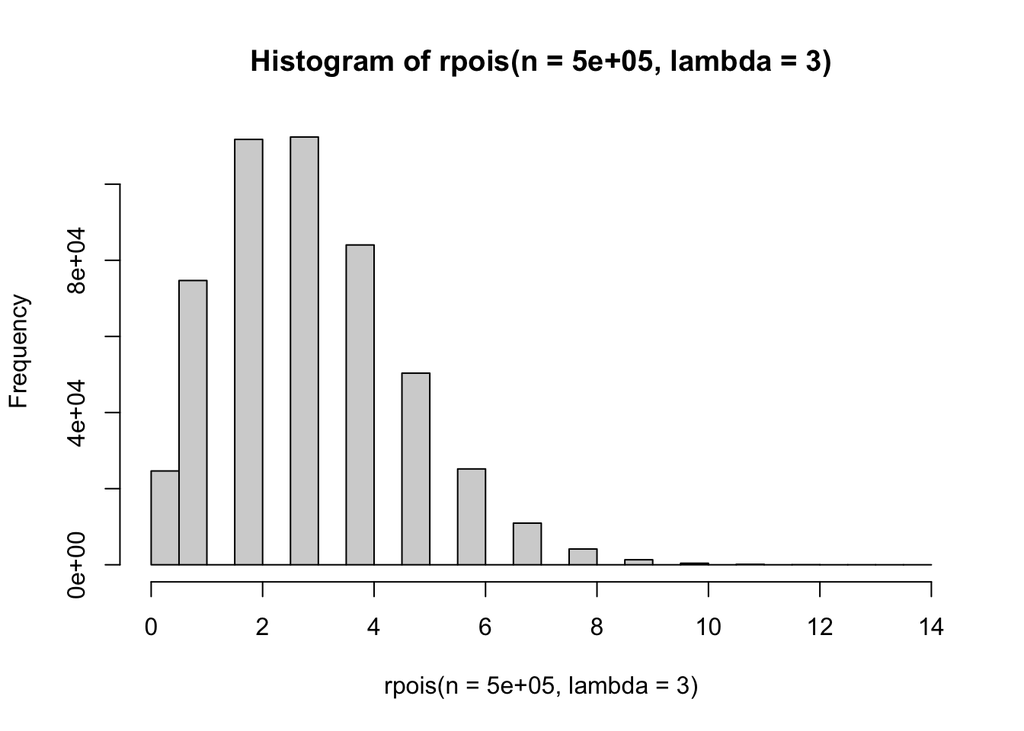

Another form of demographic stochasticity would be to consider death of each individual as a bernoulli process (e.g., a coin flip). That is, at each time step, an individual may die with some probability $d$. So at time $t$, we can flip a coin with some probability of death $d$ and some probability of not death $1-d$. This is another method to introduce stochasticity. The probability of a death can be estimated as:

$$P(death) = \frac{d}{b+d}$$

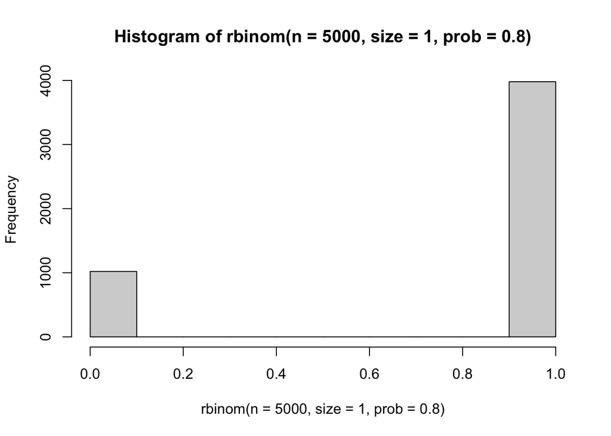

It is interesting to note here that demographic stochasticity will disproportionately influence small populations. That is, as population size goes to infinity, the effects of demographic stochasticity go to 0. But when populations are small, the potential set of outcomes (including extinction) is rather broad. The most important consequence of demographic stochasticity is an increased probability of extinction in small populations.

$$P(extinction)=(\frac{d}{b})^{N_0}$$

Even though the exact population size can not be projected precisely, we can still calcullate the *average* population size and its variance.

$$\bar{N_t} = N_0e^{rt}$$

The variance of population size at time $t$ depends on whether the birth and death rates are equal or not. If birth and death rates are equal (i.e., $r = 0$):

$$\sigma^2_{N_t} = 2N_0bt$$

### Environmental stochasticity

A second form of stochasticity is environmental stochasticity. This form of stochasticity influences populations by changing birth and death processes of all individuals in the population across time. So demographic stochasticity introduced randomness at each time step by considering the outcome of birth or death a random variable, whereas environmental stochasticity will consider the influence of the environmental conditions on resulting birth and death. This means that a death rate of 0.1 at time $t$ may change to a death rate of 0.15 (or 0.05) at time $t+1$. By drawing birth and death rates randomly from a set of feasible values (e.g., a normal distribution), we can introduce stochasticity into population dynamics.

$$r \sim Normal(\bar{r},
\sigma^2_r)$$

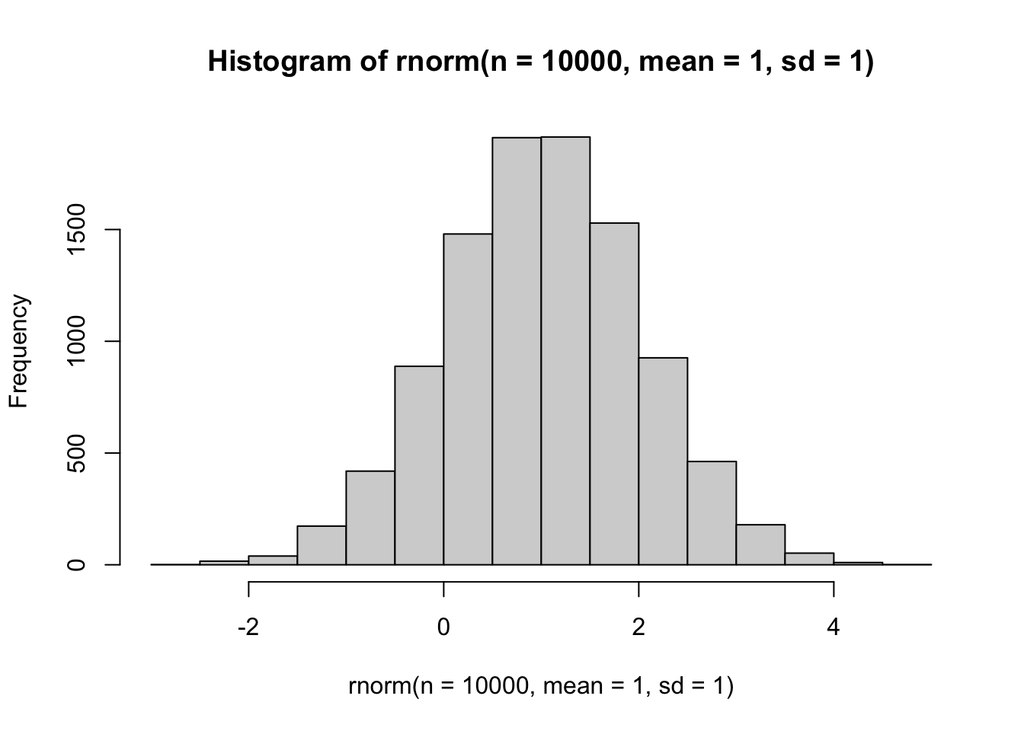

Unlike demographic stochasticity, environmental stochasticity is not *density-dependent* (i.e., the effect of environmental stochasticity is the same in small and large populations).

Mean population size:

$$\bar{N_t} = N_0e^{\bar{r}t}$$

Variance in population size:

$$\sigma^2_{N_t} =
N_0^2e^{2\bar{r}t}(e^{\sigma^2_rt}-1)$$

Extinction from envrionmental stochasticity will almost certainly happen if the variance in $r$ is greater than twice the average of $r$: $\sigma^2_r>2\bar{r}$.

## Dispersal

Dispersal of individuals in a population is a natural process. Dispersal is an important aspect of population dynamics can it can increase or decrease local population densities. Dispersal being defined as the movement of individuals in a way that allows gene flow (i.e., movement of an individual from one population to another). This is not a very satisfying definition without knowledge of the local population genetic structure, so we can simplify this, defining dispersal as the movement of individuals beyond their normal *home range*. The home range of an individual is the geographic area the individual typically encounters. So dispersal puts the individual in a new environment, which can beneficial for resource acquisition and mate finding. Dispersal is also necessary for sedentary organisms, as propagules (e.g., seeds) must somehow travel to suitable new conditions.

Dispersal can either be active or passive.

- *Active* dispersal is when the individual (or propagule) moves to a new habitat by its own accord (e.g., a mouse moving to a new burrow).
- *Passive* dispersal is when an individual (or propagule) moves to a new habitat with assistance from wind, water, or animal assistance (e.g., plant seeds dispersed by frugivores).

This is not a plant/animal divide (e.g., sponges and corals). For instance, many crustacean zooplankton (microscopic organisms which inhabit aquatic environments) may be dispersed by animals or wind. Many pathogenic bacteria and fungi of plants are dispersed by wind or water droplets during rain events.

It is also important here to differentiate *dispersal* from *migration.* Dispersal is an individual-based process of movement, often involving the movement of young away from their parents (e.g., in the extreme case, seeds, in a less extreme case, squirrels). Migration is the movement of a large number of individuals from one place or another, usually due to climatic cues, and typically with the intention of reaching a particular breeding ground (e.g., salmon) or tracking a resource (e.g., cicadas).

### Phases of dispersal

Regardless of the mode of dispersal, the act of dispersal involves three phases: departure, transfer, settlement. There are different fitness costs and benefits associated with each of these phases.

- departure: the individual moves from the current habitat
- transfer: the individual makes the journey to the new habitat
- settlement: the individual establishes itself in the new habitat

So this means that dispersal isn’t just the movement of an individual from one place to another, but the individual has to survive. This is an important distinction.

### Dispersal as a process

Dispersing individuals tend to settle and establish near their original location. This is because each stage of dispersal comes with a cost, and longer distance dispersal events tend to be rare (as mortality increases with increasing dispersal distance). But even if this weren’t the case, most individuals disperse short distances, while a small number of individuals will disperse long distances. This leads to a characteristic *dispersal kernel*. The dispersal kernel is a probability distribution of a given individual reaching a given patch during one dispersal event.

Many have claimed that dispersal is a neutral process, while others have argued that multiple cues are used by individuals deciding to disperse. So let’s first start with the assumption of neutrality and get an idea of what this would look like.

#### Neutral dispersal

Neutral dispersal would suggest that all individuals have the same probability of dispersing one unit of distance. We then allow dispersal to happen probabilistically across a landscape, with each individual dispersing some number of units. By chance, a population initiated in some area will spread out in space. It is important to note that neutral dispersal can produce a dispersal kernel similar to empirical systems. Let’s look at this.

If you have a linear landscape composed of 10 sites and we consider individuals dispersing from the far left site, probabilities of dispersal between patches are equal for all individuals, and are a function of distance. If all patches are equidistant, we have some probability $p$ of going from patch $i$ to patch $i+1$. The probability of going from patch 1 to patch 3, for instance, is $p^{2}$. The probability of going from patch 1 to patch 4 is $p^{3}$. This creates a geometric distribution (as a discrete distribution) or a negative exponential dispersal kernel (as a continuous distribution).

Thus, neutral dispersal dynamics do capture some characteristics of dispersal in natural systems. However, while neutral dispersal is a good null expectation, we will now discuss how individuals use social information to inform dispersal decisions.

#### Informed dispersal

Informed dispersal is when individuals use information on their own density, the density of a competitor or predator, or social information to inform dispersal probability and distance. Informed dispersal can also include information on resources or habitat conditions (e.g., water availability). To link the last lecture with this one, environmental stochasticity has previously been positively related with the tendency to disperse (individuals disperse more when environmental stochasticity is higher).

Evidence for informed dispersal comes from a variety of sources, including some of my own research on flour beetle dispersal. We found that dispersal probability depended on the density of a competing species, independent of overall beetle density. Additionally, the density of beetles in the neighboring habitat patch influenced dispersal probability. Lastly, we found pronounced individual variation in dispersal behavior, suggesting that some individuals are more likely to disperse than others.

### Variation in individual behavior

The dispersal kernel for a given population or species suggests that the probability of an individual dispersing $x$ distance is relatively predictable if we know the shape of that distribution. But this doesn’t consider the influence of three important things.

First, individuals may intrinsically vary in their propensity and ability to disperse, and will vary in their dispersal distances. We can imagine that species body size, wing size, genetics, body condition, etc. will all influence both *if* the individual disperses and *how far* the individual disperses.

Second, abiotic factors can strongly influence dispersal probability (i.e., if the individual disperses) and dispersal distance.

Third, species dispersal behavior is influenced by species interactions. The obvious example would be if the individual is surrounded by predators, it may not want to disperse and risk mortality. But individual dispersal behavior can also be limited by other individuals of the same species. That is, species density influences dispersal behavior.

### The influence of density on dispersal behavior

*Density-independent dispersal*: Organisms have evolved adaptations for dispersal that take advantage of various forms of kinetic energy occurring naturally in the environment. This is referred to as density independent or passive dispersal and operates on many groups of organisms (some invertebrates, fish, insects and sessile organisms such as plants) that depend on animal vectors, wind, gravity or current for dispersal.

*Density-dependent dispersal*: Density dependent or active dispersal for many animals largely depends on factors such as local population size, resource competition, habitat quality, and habitat size.

### What are the characteristics of a good disperser?

Within a single population, what makes an individual more likely to disperse?

- sex: males tend to disperse more readily, and longer distances (e.g., insects with wingless females)
- body mass: larger individuals tend to disperse more readily, and longer distances
- genotype: certain genotypes tend to disperse more readily, and longer distances (may relate to phenotypic differences that favor dispersal)

### The influence of dispersers on density

Good dispersers may have a certain set of physiological or demographic differences relative to poor dispersers. For instance, good dispersers tend to be larger bodied (though not always), fatter, and have higher fecundity. The implications of this is that areas of new colonization may have different population dynamics relative to patches that have been colonized previously. For a species shifting its range, this suggests that populations on the range edge may contain more dispersing individuals, which have different demographic rates, resulting in changes to population-level demographics.

At the species-level, there is a well established trade-off called the *competition-colonization* tradeoff. This idea is that species that are good at colonizing new habitats (i.e., those that can effectively disperse to a new habitat) tend to be poor competitors. This leads to succession (the turnover of species over time), which we will discuss in later lectures, as these early colonizers are quickly replaced by more dominant competitors (who just aren’t as good at dispersing).

### Dispersal in human-modified landscapes

Things like roads and dams present massive barriers to dispersal of many organisms. We can imagine a simple case of increased mortality or decreased dispersal probability near highways (think of all the roadkill you’ve seen on I-10). Much like geographic barriers (e.g., mountains, rivers), human-made structures can prevent dispersal (e.g., one species of snail actually speciated, diverged into two different species, as a result of a highway being built such that the geographic distribution of the species was split into two isolated halves). Another example is the building of “green bridges” across major highways. These are elevated patches of forest that go over highways, and allow large-ranged mammals and other organisms to disperse a bit more freely. Another (kind of funny) example of dispersal in human-modified landscapes is the dispersal of [fish in the presence of dams](https://www.youtube.com/watch?v=2z3ZyGlqUkA)

One the other hand, some species take advantage of human-made structures like roads. The northward expansion of the nine-banded armadillo was greatly advanced by roads, as armadillos could then walk alongside of roadways, getting over geographic barriers such as rivers. Zebra mussels are transported between lakes on the hulls of boats or through ballast water releases. Ballast water is a huge issue when it comes to the control of invasive species, as global shipping has connected areas where dispersal would never happen.